# example_rc2rot_2phi

## rc2rot RC and q calculation (2 direction (phi) data)

Method A(RC2rot): RC -> trim -> rotation

phi = 0, 120 (-120) or 0, 90 (-90)

(1) Check the angle file

(2) Rocking curve (RC)

Note: The fitting time depends on the capability of your PC.

(3) Image triming

(4) Prepare the rotating data using image_editor

(5) Calculate q

(6) re-plot and re-analysis

```python
# from pathlib import Path

# import matplotlib.pyplot as plt
# import mpl_toolkits.axes_grid1
# from mpl_toolkits.mplot3d import Axes3D

# import numpy as np
# import pandas as pd
# from PIL import Image
```

```python
from qfit import make_angle_file as maf
from qfit import fit_q
from qfit import re_analysis as rean
from qfit import re_plot as replt
from qfit import multiplot as mlplt
from qfit import image_treat as imt
from qfit import file_folder_trans as fft
```

```python
# import warnings
# warnings.simplefilter('ignore')
# # warnings.resetwarnings()
# # warnings.simplefilter('ignore', FutureWarning)
# %load_ext autoreload
# %autoreload 2
```

```python
# Set target folder path
# g_0 = r'C:\Users\USER\Desktop\XRTD\2_inch_0'
# g_120 = r'C:\Users\USER\Desktop\XRTD\2_inch_120'

g_0 = r"D:\XrayDataset_for_paper\GaN_n2_2_0"
g_120 = r"D:\XrayDataset_for_paper\GaN_n2_2_120"
```

### Check angle file

```python
# Check if it contains tif data, angle.text, and dark data.
# phi=0
_ = maf.check_holder(data_path=g_0)

# phi=120
_ = maf.check_holder(data_path=g_120)

# If the angle file does not exist, go back to creating the angle file. -> temp_anglefile.ipynb
```

```
Data path:D:\XrayDataset_for_paper\GaN_n2_2_0
Dark file exist  T/F: True
Number of all tif files : 90
Number of tif data files without dark file: 89
tif data name: ['-180000.tif', '-182500.tif', '-185000.tif', '-187500.tif', '-190000.tif']...['-390000.tif', '-392500.tif', '-395000.tif', '-397500.tif', '-400000.tif']
angle file exist T/F: True
-----
Data path:D:\XrayDataset_for_paper\GaN_n2_2_120
Dark file exist  T/F: True
Number of all tif files : 82
Number of tif data files without dark file: 81
tif data name: ['-280000.tif', '-282500.tif', '-285000.tif', '-287500.tif', '-290000.tif']...['-470000.tif', '-472500.tif', '-475000.tif', '-477500.tif', '-480000.tif']
angle file exist T/F: True
-----
```

```python
# If the angle file exists, check the angle file
maf.anglefile_info(data_path=g_0)
print('-'*5)
maf.anglefile_info(data_path=g_120)
```

```
Check angle file exist T/F: True
Read angle file:    angle     filename
0   1800  -180000.tif
1   1825  -182500.tif
2   1850  -185000.tif
3   1875  -187500.tif
4   1900  -190000.tif
Read angle file:     angle     filename
84   3900  -390000.tif
85   3925  -392500.tif
86   3950  -395000.tif
87   3975  -397500.tif
88   4000  -400000.tif
----------
-----
Check angle file exist T/F: True
Read angle file:    angle     filename
0   2800  -280000.tif
1   2825  -282500.tif
2   2850  -285000.tif
3   2875  -287500.tif
4   2900  -290000.tif
Read angle file:     angle     filename
76   4700  -470000.tif
77   4725  -472500.tif
78   4750  -475000.tif
79   4775  -477500.tif
80   4800  -480000.tif
----------
```

### RC calculation

```python
# RC hw fitting

# core: Use multi-process PC cores.
# filter: if the difference between min and max intensity < filter, then fitting values nan.
# method: hw full width half maxima

cores = 20
t_file = g_0
t_folder,_ = fit_q.fit_analysis(target_file=t_file, filter=30, method='hw', comment='0data', core=cores)
print('')

c_file = g_120
c_folder,_ = fit_q.fit_analysis(target_file=c_file, filter=30, method='hw', comment='120data', core=cores)
print('')


# RC gauss fitting
# core-> PC core Example: 20core -> 75.6s
# pmax: If peak hight < peak hight average + pmax, then fitting values nan.

# t_file = g_0
# t_folder = fit_q.fit_analysis(target_file=t_file, filter=30, pmax=30, method='gaussian', comment='0data', core=cores)
# print('')

# c_file = g_120
# c_folder = fit_q.fit_analysis(target_file=c_file, filter=30, pmax=30, method='gaussian', comment='120data', core=cores)
# print('')
```

```
0data
target file:D:\XrayDataset_for_paper\GaN_n2_2_0
Elasped time: 72.9[s] @ 20 cores
Comment: 0data
Output file name: hw_220511_122929_c.npy
Folder name: C:\Users\yagyu\Desktop\xrdt\xrdt\hw_220511_122929
----------

120data
target file:D:\XrayDataset_for_paper\GaN_n2_2_120
Elasped time: 68.3[s] @ 20 cores
Comment: 120data
Output file name: hw_220511_123041_c.npy
Folder name: C:\Users\yagyu\Desktop\xrdt\xrdt\hw_220511_123041
----------
```

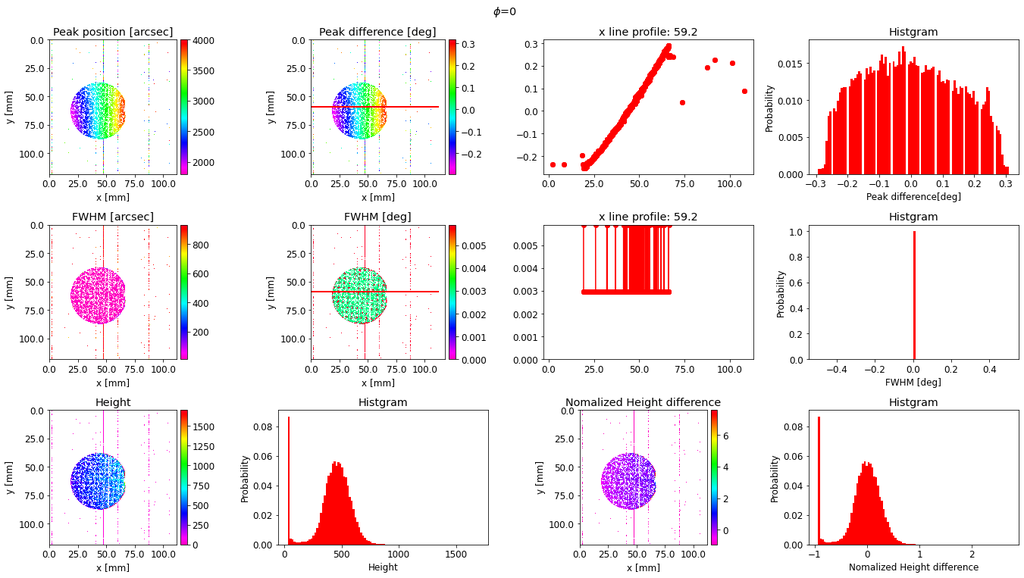

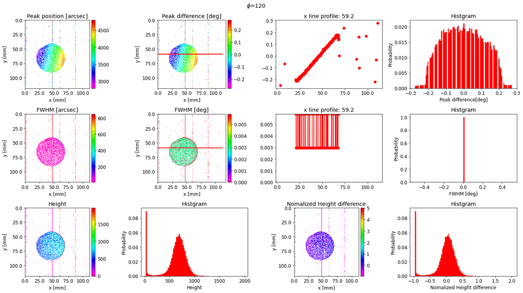

```python
# Check results
rc0 = rean.load_rc_tif(t_folder)
mlplt.rc_12plots(rc0, title='$\phi$=0')

rc120 = rean.load_rc_tif(c_folder)
mlplt.rc_12plots(rc120, title='$\phi$=120')
```

### Triming (2inch or M surface case)

[figure not shown]

- Wait a few seconds and a new GUI window will appear.
- Area select: Right-click
- Decide and quit: Press 'ESC' key

```python
# Phi=0
# 2 inch: wh(width,height)=1100, 4 inch: wh=2000, M :wh=500
#  Wait a few seconds and a new GUI window will appear.
wh4 = 2000
wh2 = 1100
whm = 500
wh_set = wh2
tr_t_folder = imt.gui2trim(t_folder, wh=wh_set, NX=2368, NY=2240, time_out=120)
```

```
(2368, 2240)
Quit -> press "ESC" Key
start x:5, y:165 --wh:1100-- end x:1105, y:1265
start x:443, y:759 --wh:1100-- end x:1543, y:1859
start x:354, y:762 --wh:1100-- end x:1454, y:1862
start x:356, y:745 --wh:1100-- end x:1456, y:1845
start x:359, y:711 --wh:1100-- end x:1459, y:1811
start x:359, y:711 --wh:1100-- end x:1459, y:1811
start x:308, y:708 --wh:1100-- end x:1408, y:1808
final x: 308, y: 708
Original h(Y), w(X) : (2368, 2240)
Trimmed h(Y), w(X) :  (1100, 1100)
Original h(Y), w(X) : (2368, 2240)
Trimmed h(Y), w(X) :  (1100, 1100)
Original h(Y), w(X) : (2368, 2240)
Trimmed h(Y), w(X) :  (1100, 1100)
```

```python
# phi=120
tr_c_folder=imt.gui2trim(c_folder, wh=wh_set, NX=2368, NY=2240, time_out=120)
```

```
(2368, 2240)
Quit -> press "ESC" Key
start x:315, y:731 --wh:1100-- end x:1415, y:1831
start x:356, y:801 --wh:1100-- end x:1456, y:1901
start x:354, y:773 --wh:1100-- end x:1454, y:1873
start x:341, y:787 --wh:1100-- end x:1441, y:1887
start x:341, y:767 --wh:1100-- end x:1441, y:1867
final x: 341, y: 767
Original h(Y), w(X) : (2368, 2240)
Trimmed h(Y), w(X) :  (1100, 1100)
Original h(Y), w(X) : (2368, 2240)
Trimmed h(Y), w(X) :  (1100, 1100)
Original h(Y), w(X) : (2368, 2240)
Trimmed h(Y), w(X) :  (1100, 1100)
```

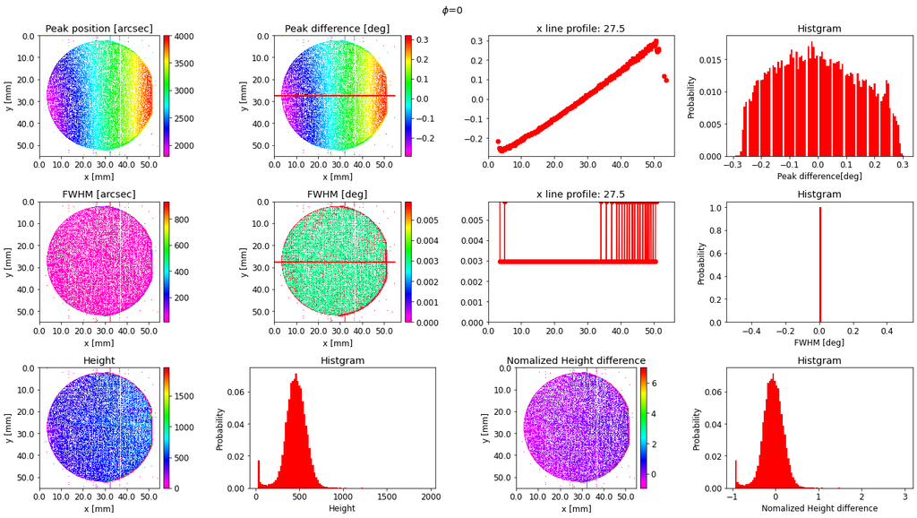

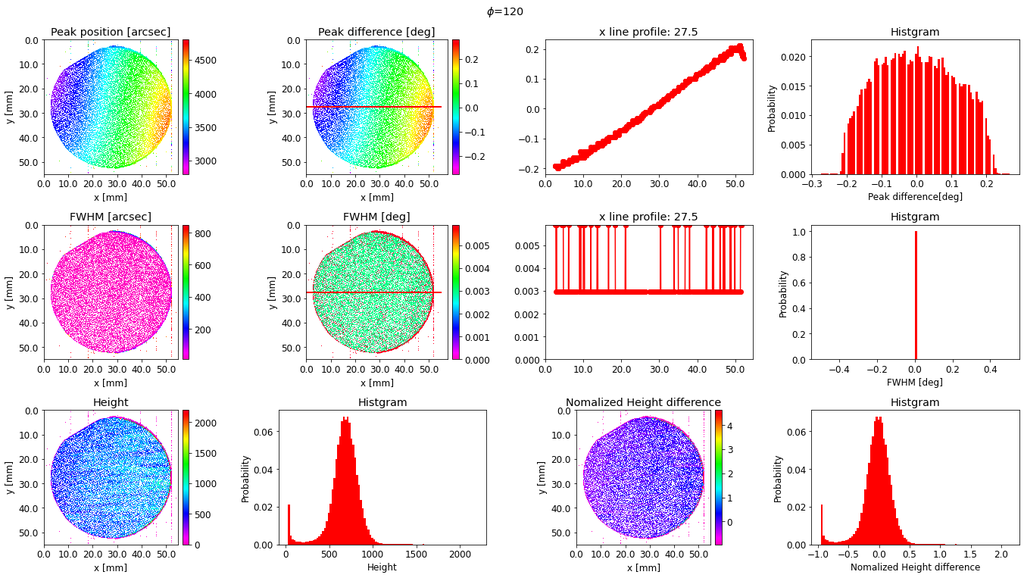

```python
# Check results
rc0 = rean.load_rc_tif(tr_t_folder)
mlplt.rc_12plots(rc0, title='$\phi$=0')

rc120 = rean.load_rc_tif(tr_c_folder)
mlplt.rc_12plots(rc120, title='$\phi$=120')

# mlplt.rc_3plots(rc120, title='$\phi$=120')
```

### Rotating image using Image_editor

[figure not shown]

(1) Upper left window: Select data folder (phi=0)

(2) Set the reading step (1: all files, default 16)

(3) Middle left window: Select data folder (e.g. phi=120)

(4) Set the reading step (1: All files, default 16)

(5) If you need to flip the x-direction, set the scale original x to -1.

(6) Change the x,y, rotation, and scale parameters.

(7) Export from the File menu.

(8) Quit from the File menu.

```python
#  Wait a few seconds and a new GUI window will appear.
outfolderlist,_ = imt.img_editor_process()
print(outfolderlist)

# out put folder name :rot_ + 'load folder name' ex: rot_tr_hw_220208_132247
# if missing outfolderlist, input the folder name.
# outfolderlist = ['','']
```

```
[WindowsPath('C:/Users/yagyu/Desktop/xrdt/xrdt/rot_tr_hw_220511_122929'), WindowsPath('C:/Users/yagyu/Desktop/xrdt/xrdt/rot_tr_hw_220511_123041')]
```

### Q calculation

```python
# Set the data folder after rotation.

# fr0=r'C:\Users\USER\Desktop\XRTD\xrdt\tr_hw_211226_215327'
# fr120=r'C:\Users\USER\Desktop\XRTD\xrdt\tr_hw_211226_215523'

fr0 = outfolderlist[0]
fr120 = outfolderlist[1]

print(fr0,fr120)
```

```
C:\Users\yagyu\Desktop\xrdt\xrdt\rot_tr_hw_220511_122929 C:\Users\yagyu\Desktop\xrdt\xrdt\rot_tr_hw_220511_123041
```

```python
# convert tif to npy

r0 = fft.conv_tif2npy(file_dir=fr0)
r120 = fft.conv_tif2npy(file_dir=fr120)

# fft.fd_tif2fd_npy(file_dir=fr0)
# fft.fd_tif2fd_npy(file_dir=fr120)

# r0=fft.folder_file_list(fr0,look_for='npy')
# r120=fft.folder_file_list(fr120,look_for='npy')

print('phi=0')
print(r0)

print('phi=120')
print(r120)
```

```
npy list:[WindowsPath('C:/Users/yagyu/Desktop/xrdt/xrdt/rot_tr_hw_220511_122929/rot_tr_hw_220511_122929_c.npy'), WindowsPath('C:/Users/yagyu/Desktop/xrdt/xrdt/rot_tr_hw_220511_122929/rot_tr_hw_220511_122929_h.npy'), WindowsPath('C:/Users/yagyu/Desktop/xrdt/xrdt/rot_tr_hw_220511_122929/rot_tr_hw_2205…
npy list:[WindowsPath('C:/Users/yagyu/Desktop/xrdt/xrdt/rot_tr_hw_220511_123041/rot_tr_hw_220511_123041_c.npy'), WindowsPath('C:/Users/yagyu/Desktop/xrdt/xrdt/rot_tr_hw_220511_123041/rot_tr_hw_220511_123041_h.npy'), WindowsPath('C:/Users/yagyu/Desktop/xrdt/xrdt/rot_tr_hw_220511_123041/rot_tr_hw_2205…
phi=0
[WindowsPath('C:/Users/yagyu/Desktop/xrdt/xrdt/rot_tr_hw_220511_122929/rot_tr_hw_220511_122929_c.npy'), WindowsPath('C:/Users/yagyu/Desktop/xrdt/xrdt/rot_tr_hw_220511_122929/rot_tr_hw_220511_122929_h.npy'), WindowsPath('C:/Users/yagyu/Desktop/xrdt/xrdt/rot_tr_hw_220511_122929/rot_tr_hw_220511_122929…
phi=120
[WindowsPath('C:/Users/yagyu/Desktop/xrdt/xrdt/rot_tr_hw_220511_123041/rot_tr_hw_220511_123041_c.npy'), WindowsPath('C:/Users/yagyu/Desktop/xrdt/xrdt/rot_tr_hw_220511_123041/rot_tr_hw_220511_123041_h.npy'), WindowsPath('C:/Users/yagyu/Desktop/xrdt/xrdt/rot_tr_hw_220511_123041/rot_tr_hw_220511_123041…
```

```python
# The '_c.npy' file is used to calculate q.

# if trimg,  NX and NY must be set to new values.

target_t_ = r0[0]
target_c_ = r120[0]

# set output folder name
out_file_ = '2R_0120'
# phi=0
set_angle_t = 0
# phi=120
set_angle_c = 120

# If it is trimmed, change NX, NY.
out_q_folder = fit_q.q_analysis_2R(target_t=target_t_, target_c=target_c_, out_file=out_file_,
                                    angle_t=set_angle_t, angle_c=set_angle_c,
                                    q=6.258 ,NX=wh_set, NY=wh_set)
```

```
outfile name:2R_0120
Image Size (h(NY),w(NX)):(1100, 1100)
set Angle t: 0, c: 120
set target t: C:\Users\yagyu\Desktop\xrdt\xrdt\rot_tr_hw_220511_122929\rot_tr_hw_220511_122929_c.npy, c: C:\Users\yagyu\Desktop\xrdt\xrdt\rot_tr_hw_220511_123041\rot_tr_hw_220511_123041_c.npy
['NEW\r', 'set Angle t:0, c:120\r', '2R_0120_f.png\r', 'Figure(640x480)\r', '']
----------
```

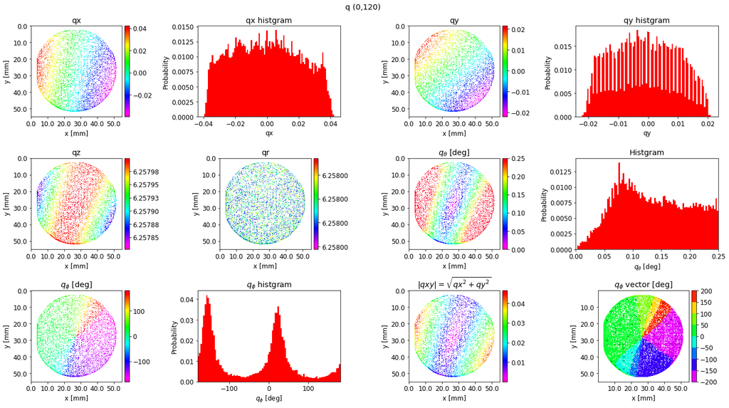

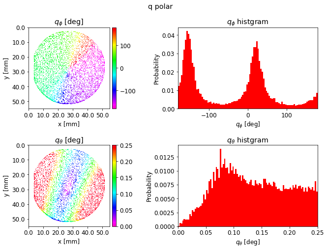

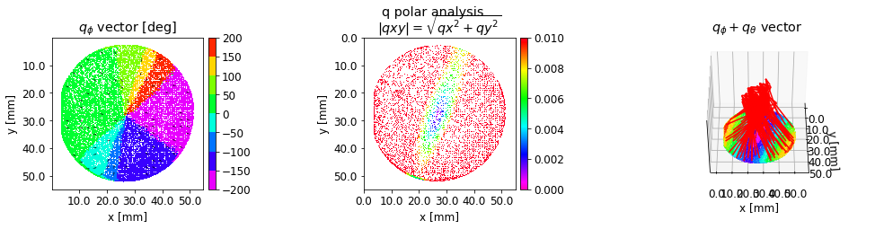

```python
# Check results
q_0120 = rean.load_q_tif(out_q_folder)
mlplt.qcp_12plots(q_0120,title='q (0,120)',step=50)
mlplt.qp_4plots(q_0120, title='q polar')
mlplt.qpa_3plots(q_0120, title='q polar analysis',step=50)
```